# ML-Problem-Set-1

Gyongyver Kamenar (2103380)

2/22/2022

Loading libraries

```r
library(tidyverse)
library(ggplot2)
library(kableExtra)
# My theme
devtools::source_url('https://raw.githubusercontent.com/gyongyver-droid/ceu-data-analysis/master/Assignment1/theme_gyongyver.R')
theme_set(theme_gyongyver())
```

# Problem 1

## A)

Write a function that implements the local averaging estimator

```r
LocalAveraging<-function(sample_x, sample_y, x, h){
  sum(sample_y * ifelse( abs(sample_x - x)<=(h/2),1,0)) / sum(ifelse( abs(sample_x - x)<=(h/2),1,0))
}
```

## B)

Generate a sample of n = 300 observations from the model

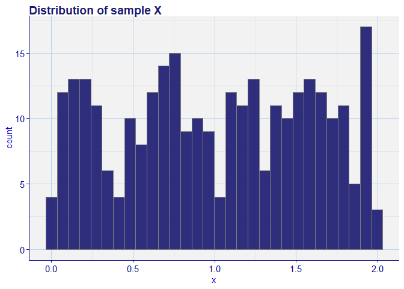

```r
#set.seed(2323)
sample_x <- runif(300, min=0, max = 2)
#set.seed(2323)
e <- rnorm(300, mean = 0, sd=1)
sample_y <- sample_x^3 - 3.5 * sample_x^2 + 3 * sample_x + e
optimal_y <- sample_x^3 - 3.5 * sample_x^2 + 3 * sample_x
# Visualize
ggplot(data.frame("x"=sample_x), aes(x))+ geom_histogram(fill="midnightblue", color="grey50", alpha=0.9)+labs(title = "Distribution of sample X")
```

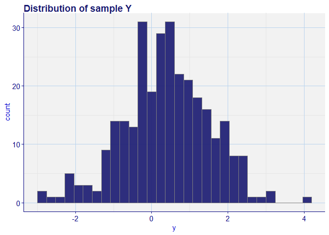

```r
ggplot(data.frame("y"=sample_y), aes(y))+ geom_histogram(fill="midnightblue", color="grey50", alpha=0.9)+labs(title = "Distribution of sample Y")
```

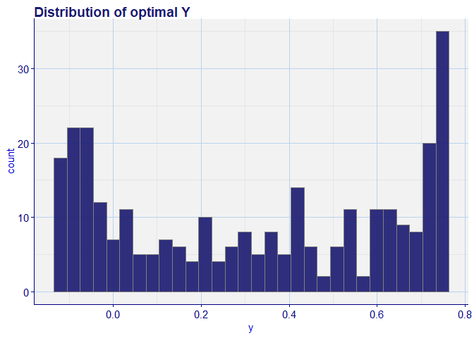

```r
ggplot(data.frame("y"=optimal_y), aes(y))+ geom_histogram(fill="midnightblue", color="grey50", alpha=0.9)+labs(title = "Distribution of optimal Y")
```

## C)

Estimate f∗(x) = E(Y | X = x) at x = 1 and x = 0.1 for a fine grid of bandwidthvalues over [0.05,2].

```r
# Calc
bandwidth_values <- seq(0.05,2,0.05)
# x=1
map_dbl(bandwidth_values,  ~{ LocalAveraging(sample_x = sample_x, sample_y = sample_y, x=1, h=.x)} )
```

```
##  [1] 0.8893268 0.8545269 0.8523450 0.4412325 0.6410096 0.6828354 0.6442072
##  [8] 0.5747424 0.6084466 0.5728919 0.5117683 0.4820806 0.4924486 0.5172447
## [15] 0.4958030 0.5063467 0.4811151 0.4804987 0.4696667 0.4469873 0.4623483
## [22] 0.4473382 0.4591318 0.4498747 0.4607059 0.4451721 0.4306074 0.4180334
## [29] 0.4538404 0.4229249 0.4218206 0.3896739 0.4068835 0.4290893 0.4220798
## [36] 0.4274794 0.4275756 0.4148230 0.4021684 0.3898251
```

```r
# x=0.1
map_dbl(bandwidth_values,  ~{ LocalAveraging(sample_x = sample_x, sample_y = sample_y, x=0.1, h=.x)} )
```

```
##  [1] 0.6926655 0.4992081 0.6396996 0.5838692 0.5785605 0.5678541 0.5595269
##  [8] 0.6624394 0.6500935 0.6389382 0.6389382 0.6382108 0.6382108 0.6697581
## [15] 0.6415688 0.6665405 0.7009429 0.7100202 0.7153930 0.6951059 0.7168811
## [22] 0.7020826 0.7107243 0.7226294 0.6795255 0.6546500 0.6649454 0.6654276
## [29] 0.6867346 0.6862620 0.7030437 0.7273789 0.7283440 0.7283440 0.7260969
## [36] 0.7288837 0.7314663 0.7389958 0.7402672 0.6867532
```

## D)

Repeat steps b) and c) many times, say, 1000. Compute bias^2, Var[f^h(x)] andMSE[f^h(x)] = bias2[f^h(x)] + Var[f^h(x)] for each h and x = 0.1, 1. Plot these quantities as a function of h.

```r
SimulateLocalAverage<-function(x_point=1, bandwidth=seq(0.05,2,0.05), sample_size=300){
  # Generate sample
  sample_x <- runif(sample_size, min=0, max = 2)
  e <- rnorm(sample_size)
  sample_y <- sample_x^3 - 3.5 * sample_x^2 + 3 * sample_x + e
  optimal_y <- sample_x^3 - 3.5 * sample_x^2 + 3 * sample_x
  # Local averaging
  #loc_avg <- LocalAveraging(sample_x = sample_x, sample_y = sample_y, x=x_point, h=bandwidth)

  map_df(bandwidth, ~{
    tibble(
    bandwidth = .x,
    loc_avg = as.numeric(LocalAveraging(sample_x = sample_x, sample_y = sample_y, x=x_point, h=.x )),
    error = as.numeric((x_point^3 - 3.5 * x_point^2 + 3 * x_point) - loc_avg)
    )
  })
}

# Simulate 1000 times
n <-1000
# x_point = 1
results_df_x1 <-data.frame()
for(i in 1:n){
  results_df_x1<- rbind(results_df_x1, SimulateLocalAverage(x=1))

}
results_df_x1 %>% group_by(bandwidth) %>% summarise(bias=mean(error)^2, var = var(loc_avg), mse=bias+var)
```

| bandwidth | bias | var | mse |
| --- | --- | --- | --- |
| 0.05 | NaN | NA | NaN |
| 0.10 | 6.257066e-05 | 0.071756538 | 0.071819109 |
| 0.15 | 1.007508e-04 | 0.047155036 | 0.047255787 |
| 0.20 | 5.647317e-05 | 0.035510723 | 0.035567196 |
| 0.25 | 8.145920e-05 | 0.027726455 | 0.027807914 |
| 0.30 | 5.593813e-05 | 0.023256320 | 0.023312258 |
| 0.35 | 8.259664e-05 | 0.019658169 | 0.019740765 |
| 0.40 | 1.107039e-04 | 0.017003133 | 0.017113837 |
| 0.45 | 2.067392e-04 | 0.014891311 | 0.015098050 |
| 0.50 | 2.576383e-04 | 0.013669327 | 0.013926966 |

[output cut: 30 more lines]

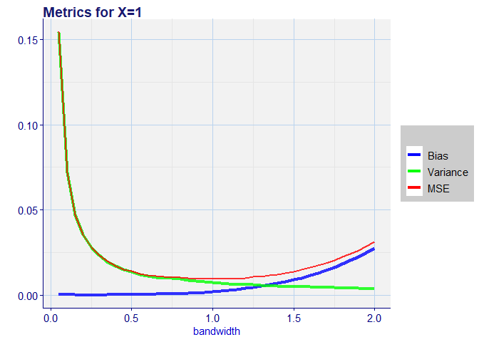

```r
# Visualize function
VisualizeResult<-function(results){
  results %>% group_by(bandwidth) %>% summarise(bias = mean(error, na.rm=T)^2, var = var(loc_avg,na.rm = T), mse=bias+var) %>%
    ggplot(aes(x=bandwidth))+
    geom_line(aes(y=bias, color="Bias"), size=1.5, alpha=0.8)+
    geom_line(aes(y=var, color="Variance"),size=1.5, alpha=0.8)+
    geom_line(aes(y=mse, color="MSE"),size=1, alpha=0.8)+
    scale_colour_manual("",
                      breaks = c("Bias", "Variance", "MSE"),
                      values = c("blue", "green", "red"))+
    labs(y="")
}


VisualizeResult(results_df_x1)+ labs(title = "Metrics for X=1", y="")
```

```r
# x_point = 0.1
results_df_x01 <-data.frame()
for(i in 1:n){
  results_df_x01<- rbind(results_df_x01, SimulateLocalAverage(x=0.1))

}

results_df_x01 %>% group_by(bandwidth) %>% summarise(bias=mean(error)^2, var = var(loc_avg), mse=bias+var)
```

| bandwidth | bias | var | mse |
| --- | --- | --- | --- |
| 0.05 | NaN | NA | NaN |
| 0.10 | 5.376079e-04 | 0.070951234 | 0.07148884 |
| 0.15 | 3.823892e-04 | 0.048872385 | 0.04925477 |
| 0.20 | 4.574505e-04 | 0.036273658 | 0.03673111 |
| 0.25 | 4.122682e-05 | 0.032652921 | 0.03269415 |
| 0.30 | 1.211856e-03 | 0.029383102 | 0.03059496 |
| 0.35 | 3.343362e-03 | 0.026831377 | 0.03017474 |
| 0.40 | 6.414893e-03 | 0.024791208 | 0.03120610 |
| 0.45 | 1.025600e-02 | 0.023038016 | 0.03329401 |
| 0.50 | 1.419033e-02 | 0.021272613 | 0.03546295 |

[output cut: 30 more lines]

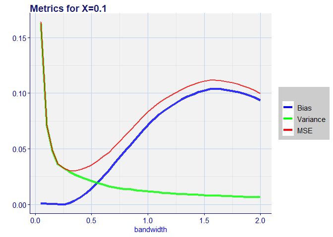

```r
# Visualize
VisualizeResult(results_df_x01)+ labs(title = "Metrics for X=0.1", y="")
```

## E)

Interpret the patterns you see in the plots produced under part d). In particular, compare the bias for x = 0.1 and x = 1. Can you propose an explanation for the difference?

Comparing the 2 plots we can see, that the variance (as the function of bandwidth) is similar for both evaluation point. However, the bias is really different. In the case of x=1 we can see that the bias is around 0 and than it is just slightly increasing after that. In the case of x=0.1 evaluation point the bias is around 0 until 0.25 bandwidth and that it’s steeply increasing (and somewhat diminishing around 1.6 but not relevantly) .

I my opinion, it can be explained by the distribution of $X ~unif(min=0, max=2)$ sample. So if we pick the evaluation point x=1, it is in the middle of the sample, so for each chosen bandhwidth the distribution of local X values will be “symmetric” around x=1.

However, if we pick the evaluation point x=0.1 it is at the edge of the sample. The minimum of x sample is 0, so for bandwidth > 0.2 we will include $ X_i$ values above the evaluation point, because basically there are no more points below 0.1 - (0.2/2)=0. Therefore, we introduce an upward bias based on the local average estimator.

# Problem 2

## A)

Generate a sample of size n = 1000 from the model with k = 5 and k = 8. Implement the local averaging estimator ˆfh(x) for h = 1, 1.5, 2, 2.5, 3, 3.5, 4. You will find that the estimator is often not well defined for the smaller values of h. Why? Make sure that your code can handle this event, i.e., it does not stop running with an error message.

I implemented a new local averaging function which can handle multi-dimentional predictors:

```r
LocalAveraging2<-function(sample_x, sample_y, x=1, h=seq(1,4,0.5)){
  sum(sample_y * ifelse( map_dbl(seq(nrow(sample_x)), ~norm(as.matrix(sample_x[.x,]- x), type = "f"))<=(h/2),1,0))/ sum(ifelse(map_dbl(seq(nrow(sample_x)), ~norm(as.matrix(sample_x[.x,]- x), type = "f"))<=(h/2),1,0))

}
LocalAveraging3<-function(sample_x, sample_y, x=1, h=seq(1,4,0.5)){
  mean(sample_y * ifelse( map_dbl(seq(nrow(sample_x)), ~norm(as.matrix(sample_x[.x,]- x), type = "f"))<=(h/2),1,0))
}
# k=5 simulation
n <- 1000
k <- 5
h <- seq(1,4,0.5)
x=1
sample_x <- matrix(rnorm(n * k, mean = 0, sd=2), nrow = n, ncol = k)
e <- rnorm(n,0,1)
sample_y <- map_dbl(seq_len(n), ~prod(sample_x[.x,])+e[.x])+1
# estimates
map_dbl(h, ~LocalAveraging3(sample_x = sample_x, sample_y = sample_y, x=1, h=.x) )
```

```
## [1] 0.000000000 0.003488379 0.003488379 0.004818893 0.007675471 0.025597509
## [7] 0.033474911
```

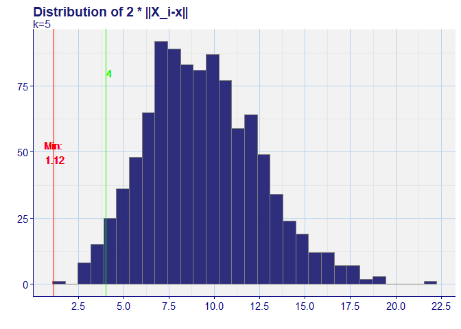

```r
# why?
x_vector = 2*(map_dbl(seq(nrow(sample_x)), ~norm(as.matrix(sample_x[.x,]- x), type = "f")))
ggplot(data.frame("X"=x_vector), aes(X))+
  geom_histogram(fill="midnightblue", color="grey50", alpha=0.9)+
  labs(title = "Distribution of 2 * ||X_i-x||", subtitle = "k=5",y="",x="")+
  scale_x_continuous(breaks = seq(0,22.5,2.5))+
  geom_vline(aes(xintercept=min(X)), color="red")+
  geom_text(aes(x=min(X), y=50, label=paste("Min:\n",round(min(X),3))), color="red")+
  geom_vline(aes(xintercept=4),color="green")+
  geom_text(aes(x=4.2, y=80, label="4"), color="green")+
  theme(legend.position = "none")
```

The values of $2 * || X_i-x ||$ are mostly above $h=4$ as we can see on the above histogram. The minimum value is 1.12 so for $h$ below that, we do not have any observation to evaluate, the nominator and denominator of the local averaging function will be 0. Therefore the local average estimator cannot be defined in these cases. My function will give NA-s, which I can filter for before calculating the needed measures.

```r
# k=8 simulation
n <- 1000
k <- 8
h <- seq(1,4,0.5)
sample_x <- matrix(rnorm(n * k, mean = 0, sd=2), nrow = n, ncol = k)
e <- rnorm(n,0,1)
sample_y <- map_dbl(seq_len(n), ~prod(sample_x[.x,])+e[.x])+1
# estimates
map_dbl(h, ~LocalAveraging2(sample_x = sample_x, sample_y = sample_y, x=1, .x) )
```

```
## [1]        NaN        NaN        NaN        NaN        NaN        NaN 0.09003515
```

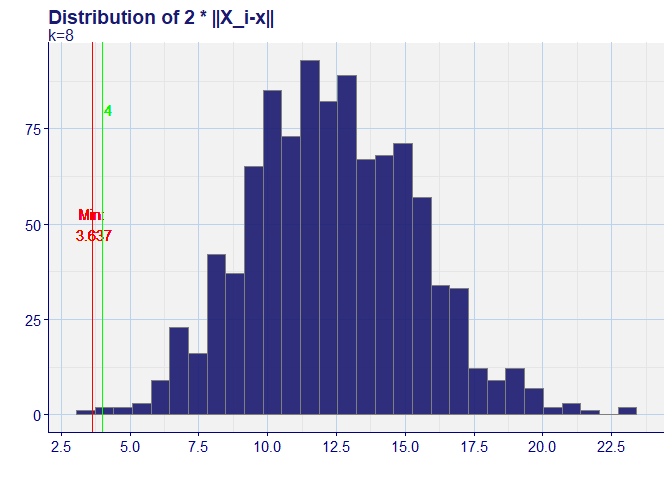

```r
# Why
x_vector = 2*(map_dbl(seq(nrow(sample_x)), ~norm(as.matrix(sample_x[.x,]- x), type = "f")))
ggplot(data.frame("X"=x_vector), aes(X))+
  geom_histogram(fill="midnightblue", color="grey50", alpha=0.9)+
  labs(title = "Distribution of 2 * ||X_i-x||", subtitle = "k=8", y="",x="")+
  scale_x_continuous(breaks = seq(0,22.5,2.5))+
  geom_vline(aes(xintercept=min(X)), color="red")+
  geom_text(aes(x=min(X), y=50, label=paste("Min:\n",round(min(X),3))), color="red")+
  geom_vline(aes(xintercept=4),color="green")+
  geom_text(aes(x=4.2, y=80, label="4"), color="green")+
  theme(legend.position = "none")
```

The same is the case for $k=8$ but the values are higher as you can see on the histogram above. The minimum of $2 * || X_i-x ||$ is 3.637 so for $h$ below that the estimator will not be defined.

## B)

Repeat part a) many times, say, 1000. For each value of h, report i) the % of the time that the estimator was well defined; ii) the bias of the estimator; iii) the standard deviation of the estimator; iv) the root mean squared error ((bias2 + var)1/2) as a percentage of the true value of E(Y | X = x). (When you calculate the bias, standard deviation, etc., use only the cases in which the estimator was well defined.)

### k=5

```r
# Simulation function

SimulateModel2<-function(n=1000,k=5,h=seq(1,4,0.5)){
  # Generate sample
  sample_x <- matrix(rnorm(n * k, mean = 0, sd=2), nrow = n, ncol = k)
  e <- rnorm(n,0,1)
  sample_y <- map_dbl(seq_len(n), ~prod(sample_x[.x,])+e[.x])+1
  x_eval <- matrix(1, ncol = dim(sample_x)[2])

  #Estimation
  map_df(h,
         ~{
           tibble(bandwidth = .x,
                  loc_avg =as.numeric(LocalAveraging2(sample_x = sample_x, sample_y = sample_y, x=1, .x)),
                  error = as.numeric((prod(x_eval)+1) - loc_avg)
           ) }

         )

}

results_k5<-map_df(seq(1000), SimulateModel2 )
results_k5
```

| bandwidth | loc_avg | error |
| --- | --- | --- |
| 1.0 | NaN | NaN |
| 1.5 | NaN | NaN |
| 2.0 | NaN | NaN |
| 2.5 | NaN | NaN |
| 3.0 | NaN | NaN |
| 3.5 | NaN | NaN |
| 4.0 | NaN | NaN |
| 1.0 | NaN | NaN |
| 1.5 | NaN | NaN |
| 2.0 | NaN | NaN |

[output cut: 6990 more lines]

```r
# % defined
GetDefined<-function(results_k){
  defined <-results_k %>% group_by(loc_avg=="NaN") %>% count()
  unlist(defined[1,2] / sum(defined[,2]) * 100)
}

GetDefined(results_k5)
```

```
##  n
## 54
```

```r
# bias, sd, RMSE
SummariseError<-function(simulated_data){
  simulated_data %>% group_by(bandwidth) %>% summarise(mean_f_hat=mean(loc_avg,na.rm=T),
                                                       defined_rate=sum(!is.na(loc_avg)) /(sum(is.na(loc_avg))+sum(!is.na(loc_avg))),
                                                       Bias = mean(error, na.rm=T)^2, SD =sd(loc_avg, na.rm = TRUE),
                                                       RMSE = sqrt(Bias+var(loc_avg, na.rm = T)) )
}

summary<-SummariseError(results_k5)
summary
```

| bandwidth | mean_f_hat | defined_rate | Bias | SD | RMSE |
| --- | --- | --- | --- | --- | --- |
| 1.0 | 2.377369 | 0.006 | 0.14240769 | 0.8715056 | 0.9496998 |
| 1.5 | 1.886750 | 0.093 | 0.01282558 | 1.2485695 | 1.2536951 |
| 2.0 | 1.737953 | 0.329 | 0.06866872 | 1.2334174 | 1.2609469 |
| 2.5 | 1.732487 | 0.628 | 0.07156319 | 1.2080802 | 1.2373444 |
| 3.0 | 1.667374 | 0.836 | 0.11064037 | 1.1108169 | 1.1595493 |
| 3.5 | 1.538837 | 0.928 | 0.21267122 | 0.8611340 | 0.9768433 |
| 4.0 | 1.441087 | 0.960 | 0.31238419 | 0.7810606 | 0.9604373 |

```r
# Metrics as the rate of true value
MetricRate<-function(summary_data,true_value=2){
 summary_data %>% summarise(bandwidth,Bias, SD,RMSE,defined_rate, Bias_rate = Bias/true_value, SD_rate = SD/true_value, RMSE_rate=RMSE/true_value)
}

MetricRate(summary)
```

| bandwidth | Bias | SD | RMSE | defined_rate | Bias_rate | SD_rate | RMSE_rate |
| --- | --- | --- | --- | --- | --- | --- | --- |
| 1.0 | 0.14240769 | 0.8715056 | 0.9496998 | 0.006 | 0.07120384 | 0.4357528 | 0.4748499 |
| 1.5 | 0.01282558 | 1.2485695 | 1.2536951 | 0.093 | 0.00641279 | 0.6242848 | 0.6268476 |
| 2.0 | 0.06866872 | 1.2334174 | 1.2609469 | 0.329 | 0.03433436 | 0.6167087 | 0.6304735 |
| 2.5 | 0.07156319 | 1.2080802 | 1.2373444 | 0.628 | 0.03578160 | 0.6040401 | 0.6186722 |
| 3.0 | 0.11064037 | 1.1108169 | 1.1595493 | 0.836 | 0.05532018 | 0.5554085 | 0.5797747 |
| 3.5 | 0.21267122 | 0.8611340 | 0.9768433 | 0.928 | 0.10633561 | 0.4305670 | 0.4884217 |
| 4.0 | 0.31238419 | 0.7810606 | 0.9604373 | 0.960 | 0.15619209 | 0.3905303 | 0.4802187 |

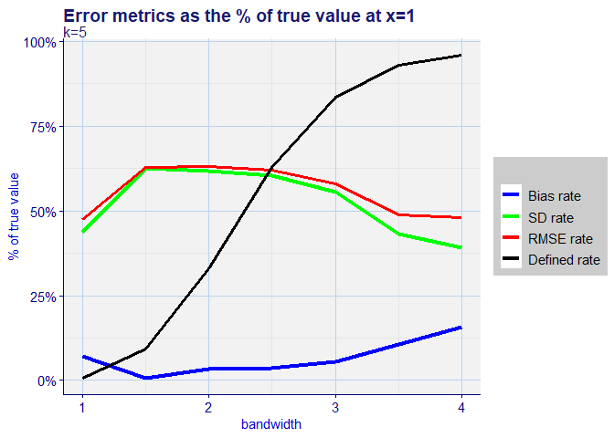

```r
# Visualize
ShowMetricRate<-function(data){
  ggplot(data, aes(x=bandwidth))+
    geom_line(aes(y=Bias_rate, color="Bias rate"), size=1.5)+
    geom_line(aes(y=SD_rate, color="SD rate"), size=1.5)+
    geom_line(aes(y=RMSE_rate, color="RMSE rate"), size=1.3)+
    geom_line(aes(y=defined_rate, color="Defined rate"), size=1.1)+
    scale_colour_manual("",
                      breaks = c("Bias rate", "SD rate", "RMSE rate","Defined rate"),
                      values = c("blue", "green", "red", "black"))+
    labs(y="% of true value", title = "Error metrics as the % of true value at x=1")+
    scale_y_continuous(labels = scales::percent)
}

k5<-MetricRate(summary) %>%  ShowMetricRate()+labs(subtitle = "k=5")
k5
```

### k=8

```r
results_k8<-data.frame()
results_k8<-map_df(seq(1000), SimulateModel2,k=8 )
results_k8
```

| bandwidth | loc_avg | error |
| --- | --- | --- |
| 1.0 | NaN | NaN |
| 1.5 | NaN | NaN |
| 2.0 | NaN | NaN |
| 2.5 | NaN | NaN |
| 3.0 | NaN | NaN |
| 3.5 | NaN | NaN |
| 4.0 | NaN | NaN |
| 1.0 | NaN | NaN |
| 1.5 | NaN | NaN |
| 2.0 | NaN | NaN |

[output cut: 6990 more lines]

```r
# defined, bias, sd, RMSE
SummariseError(results_k8)
```

| bandwidth | mean_f_hat | defined_rate | Bias | SD | RMSE |
| --- | --- | --- | --- | --- | --- |
| 1.0 | NaN | 0.000 | NaN | NA | NaN |
| 1.5 | NaN | 0.000 | NaN | NA | NaN |
| 2.0 | 2.697846 | 0.002 | 0.4869888 | 0.3067125 | 0.7622738 |
| 2.5 | 1.192682 | 0.012 | 0.6517618 | 1.0879328 | 1.3547544 |
| 3.0 | 1.188699 | 0.039 | 0.6582101 | 1.0018485 | 1.2891510 |
| 3.5 | 1.469056 | 0.120 | 0.2819015 | 2.1424504 | 2.2072597 |
| 4.0 | 1.391687 | 0.279 | 0.3700449 | 2.1310405 | 2.2161630 |

```r
# Get rate as the true value
SummariseError(results_k8) %>% MetricRate()
```

| bandwidth | Bias | SD | RMSE | defined_rate | Bias_rate | SD_rate | RMSE_rate |
| --- | --- | --- | --- | --- | --- | --- | --- |
| 1.0 | NaN | NA | NaN | 0.000 | NaN | NA | NaN |
| 1.5 | NaN | NA | NaN | 0.000 | NaN | NA | NaN |
| 2.0 | 0.4869888 | 0.3067125 | 0.7622738 | 0.002 | 0.2434944 | 0.1533563 | 0.3811369 |
| 2.5 | 0.6517618 | 1.0879328 | 1.3547544 | 0.012 | 0.3258809 | 0.5439664 | 0.6773772 |
| 3.0 | 0.6582101 | 1.0018485 | 1.2891510 | 0.039 | 0.3291050 | 0.5009242 | 0.6445755 |
| 3.5 | 0.2819015 | 2.1424504 | 2.2072597 | 0.120 | 0.1409507 | 1.0712252 | 1.1036298 |
| 4.0 | 0.3700449 | 2.1310405 | 2.2161630 | 0.279 | 0.1850224 | 1.0655202 | 1.1080815 |

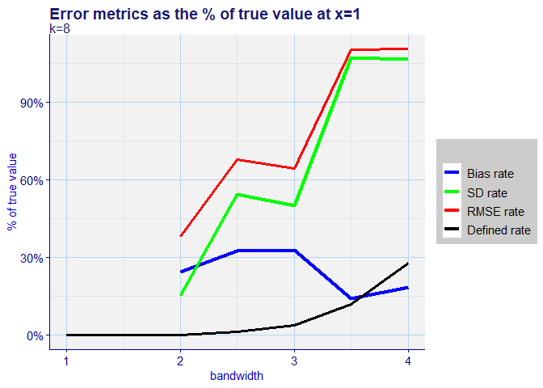

```r
# Visualize
k8<-SummariseError(results_k8) %>% MetricRate() %>% ShowMetricRate()+labs(subtitle = "k=8")
k8
```

## C)

Repeat parts a) and b) with n = 10, 000.

```r
# Simulate for n=10000
results_k5_n10000 <-data.frame()
n<-1000
for(i in 1:n){
  results_k5_n10000<- rbind(results_k5_n10000, SimulateModel2(n=10000))

}
#results_k5_n10000 <- map_df(seq(1000), SimulateModel2, n=10000, h=seq(1,4,0.5))
# % of defined
GetDefined(results_k5_n10000)
```

```
##        n
## 87.32857
```

```r
# bias, sd, rmse
SummariseError(results_k5_n10000)
```

| bandwidth | mean_f_hat | defined_rate | Bias | SD | RMSE |
| --- | --- | --- | --- | --- | --- |
| 1.0 | 1.940272 | 0.237 | 0.003567475 | 1.0848250 | 1.0864680 |
| 1.5 | 1.917818 | 0.876 | 0.006753855 | 0.9028657 | 0.9065982 |
| 2.0 | 1.826101 | 1.000 | 0.030240738 | 0.5002138 | 0.5295796 |
| 2.5 | 1.747720 | 1.000 | 0.063645118 | 0.2935365 | 0.3870514 |
| 3.0 | 1.662591 | 1.000 | 0.113845081 | 0.2064735 | 0.3955710 |
| 3.5 | 1.557926 | 1.000 | 0.195429177 | 0.1605129 | 0.4703122 |
| 4.0 | 1.455854 | 1.000 | 0.296095063 | 0.1317169 | 0.5598611 |

```r
#Get rate of the true value
SummariseError(results_k5_n10000) %>% MetricRate()
```

| bandwidth | Bias | SD | RMSE | defined_rate | Bias_rate | SD_rate | RMSE_rate |
| --- | --- | --- | --- | --- | --- | --- | --- |
| 1.0 | 0.003567475 | 1.0848250 | 1.0864680 | 0.237 | 0.001783737 | 0.54241251 | 0.5432340 |
| 1.5 | 0.006753855 | 0.9028657 | 0.9065982 | 0.876 | 0.003376927 | 0.45143284 | 0.4532991 |
| 2.0 | 0.030240738 | 0.5002138 | 0.5295796 | 1.000 | 0.015120369 | 0.25010688 | 0.2647898 |
| 2.5 | 0.063645118 | 0.2935365 | 0.3870514 | 1.000 | 0.031822559 | 0.14676823 | 0.1935257 |
| 3.0 | 0.113845081 | 0.2064735 | 0.3955710 | 1.000 | 0.056922540 | 0.10323674 | 0.1977855 |
| 3.5 | 0.195429177 | 0.1605129 | 0.4703122 | 1.000 | 0.097714588 | 0.08025644 | 0.2351561 |
| 4.0 | 0.296095063 | 0.1317169 | 0.5598611 | 1.000 | 0.148047532 | 0.06585845 | 0.2799305 |

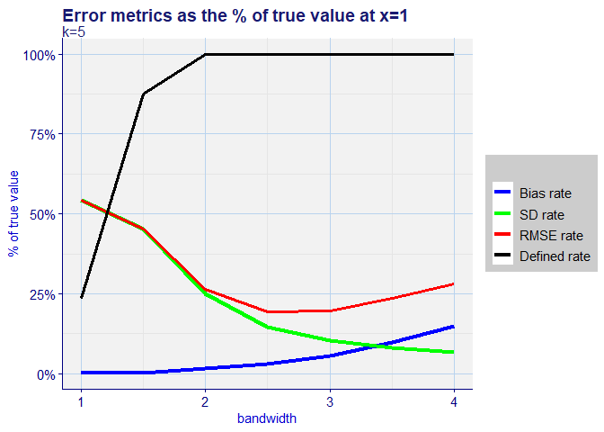

```r
# Visualize
k5_10k<-SummariseError(results_k5_n10000) %>% MetricRate() %>% ShowMetricRate()+ labs(subtitle = "k=5")
k5_10k
```

```r
results_k8_n10000 <-data.frame()
n<-1000
for(i in 1:n){
  results_k8_n10000<- rbind(results_k8_n10000, SimulateModel2(n=10000,k=8))

}
#results_k8_n10000 <- map_df(seq(1000), SimulateModel2,k=8, n=10000,h=seq(1,4,0.5))
# % of defined
GetDefined(results_k8_n10000)
```

```
##        n
## 38.65714
```

```r
# bias, sd, rmse
SummariseError(results_k8_n10000)
```

| bandwidth | mean_f_hat | defined_rate | Bias | SD | RMSE |
| --- | --- | --- | --- | --- | --- |
| 1.0 | NaN | 0.000 | NaN | NA | NaN |
| 1.5 | 2.289136 | 0.001 | 0.083599818 | NA | NA |
| 2.0 | 2.043041 | 0.020 | 0.001852564 | 1.7084736 | 1.7090157 |
| 2.5 | 1.731273 | 0.183 | 0.072214023 | 1.4586714 | 1.4832182 |
| 3.0 | 1.642768 | 0.577 | 0.127614476 | 1.5239975 | 1.5653059 |
| 3.5 | 1.590285 | 0.925 | 0.167866458 | 1.3984695 | 1.4572520 |
| 4.0 | 1.409225 | 1.000 | 0.349015002 | 0.7976145 | 0.9925744 |

```r
#Get rate of the true value
SummariseError(results_k8_n10000) %>% MetricRate()
```

| bandwidth | Bias | SD | RMSE | defined_rate | Bias_rate | SD_rate | RMSE_rate |
| --- | --- | --- | --- | --- | --- | --- | --- |
| 1.0 | NaN | NA | NaN | 0.000 | NaN | NA | NaN |
| 1.5 | 0.083599818 | NA | NA | 0.001 | 0.0417999091 | NA | NA |
| 2.0 | 0.001852564 | 1.7084736 | 1.7090157 | 0.020 | 0.0009262819 | 0.8542368 | 0.8545078 |
| 2.5 | 0.072214023 | 1.4586714 | 1.4832182 | 0.183 | 0.0361070117 | 0.7293357 | 0.7416091 |
| 3.0 | 0.127614476 | 1.5239975 | 1.5653059 | 0.577 | 0.0638072379 | 0.7619987 | 0.7826530 |
| 3.5 | 0.167866458 | 1.3984695 | 1.4572520 | 0.925 | 0.0839332288 | 0.6992348 | 0.7286260 |
| 4.0 | 0.349015002 | 0.7976145 | 0.9925744 | 1.000 | 0.1745075012 | 0.3988072 | 0.4962872 |

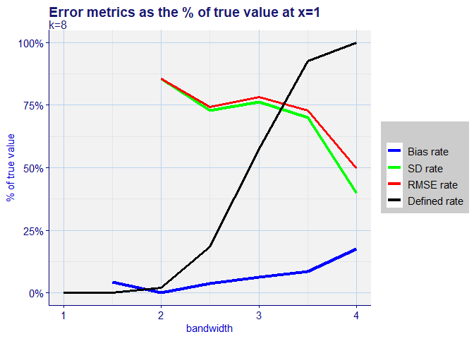

```r
# Visualize
k8_10k<-SummariseError(results_k8_n10000) %>% MetricRate() %>% ShowMetricRate() + labs(subtitle = "k=8")
k8_10k
```

## D)

Discuss the results.

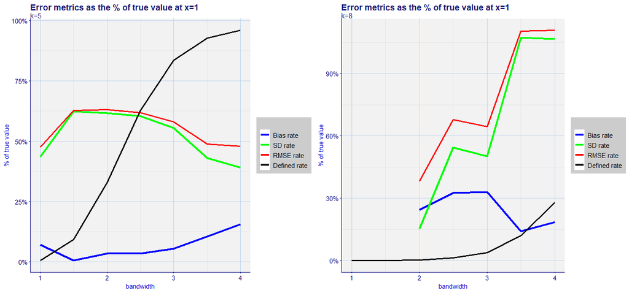

```r
library(ggpubr)
ggarrange(k5, k8, nrow=1)
```

The above charts show the metrics rate of the true value and the rate when the estimator was defined for n=1000 sample size, k=5 and k=8 dimensions respectively. For k=5 the defined rate is steeply increasing with higher bandwidth and eventually (at 4) it is reaching ~95%. The bias is relatively small but increasing while the variance is much higher (~50%) but decreasing with higher bandwidth and defined rate.

On the other hand, with k=8 dimensions the defined rate remains low by reaching only ~5% at bandwidth=3 and ~30% at bandwidth=4. Thus measures are less robust and pretty unreliable for bandwidth below 3. The bias and variance are much higher then in the k=5 case. But we cannot see the parrern of increasing bias and decreasing variance. Actually, we cannot draw lot of conclusion from the k=8 case because of the low defined rate, every single time the simulation will be different and results different bias and variance measures.

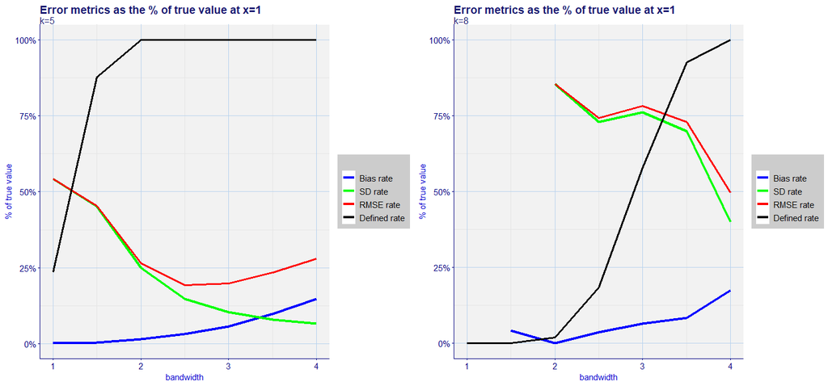

```r
ggarrange(k5_10k, k8_10k, nrow=1)
```

In the case if 10000 sample size the defined rate is much higher for both cases . It is understandable, because there are more observations in the sample, it’s more likely that any of them will be within bandwidth so the local average estimator can be defined. With higher defined rate, the bias and variance curves are also more reliable. In the case of k=5 we can clearly see that the bias is increasing and the variance is decreasing with larger bandwidth.

In the k=8 case the 10000 sample size is much better but is still only reaches ~100% defined rate around bandwidth = 4. We can somewhat see the pattern of increasing bias and decreasing variance but there are some deviation. Besides, it took ~30 times more to do the simulation with sample size = 10000.

In conclusion, the higher dimension sample require more data to appropriately evaluate and the information provided by a few more dimensions might not worth the time and effort. Besides, we have to carefully select the dimension of predictors based on the available sample data and the estimator function.

# Problem 3

## A)

Expanding the square:
$$E[(Y - \beta_0 )^2] = E[ Y^2 - 2Y\beta_0 + \beta^2]$$
$$min \beta_0 : E[ Y^2 - 2Y\beta_0 + \beta^2]$$

Derive respect to $\beta_0$ and set equal to 0 to solve the minimization problem.

$$E[ -2Y + 2\beta_0] = 0$$
$$E[\beta_0 - Y] = 0$$
$\beta_0$ is constant so we can remove the expected value of it:
$$\beta_0^* - E[Y] =0$$
$$\beta^*_0 = E[Y]$$

## B)

The OLS minimize the sum of squared residuals:

$$min \beta_0 : \sum_{i=1}^n (Y_i -\hat \beta_0 )^2$$

Derive it respect to $\hat \beta_0$ and set it equal to 0. The derivative of the sum is the sum of derivatives:

$$\sum_{i=1}^n 2 * (Y_i - \hat \beta_0)*(-1) = 0$$

$$-2 * \sum_{i=1}^n (Y_i - \hat \beta_0) = 0$$

$$\sum_{i=1}^n Y_i - \sum_{i=1}^n \hat \beta_0 = 0$$
$\hat \beta_0$ is constant so the sum can be rewrited by $n*\hat \beta_0$:

$$\sum_{i=1}^n Y_i - n * \hat \beta_0 = 0$$
$$\sum_{i=1}^n Y_i = n * \hat \beta_0$$
Expressing $\hat \beta_0$:

$$\hat \beta_0 =\frac{\sum_{i=1}^n Y_i }{n}$$
The sum of $Y_i$ divided by the number of observations is the mean.
$$\hat \beta_0 = \overline Y$$

## C)

Show that the expected value of $\hat \beta_0$ is the expected value of the true value. We can start from the formula derived in the previous part:

$$\hat \beta_0 =\frac{\sum_{i=1}^n Y_i }{n}$$
$$\hat \beta_0 =\frac{\sum_{i=1}^n \beta_0 + \epsilon_i }{n}$$
$$\hat \beta_0 =\frac{\sum_{i=1}^n \beta_0 +\sum_{i=1}^n \epsilon_i }{n}$$
Since $\epsilon$ ~ normal(0,1) i.i.d. thus $E(\epsilon) = 0$

$$\hat \beta_0 =\frac{\sum_{i=1}^n \beta_0}{n}$$
And

$$\hat \beta_0 = E(\beta_0)$$